# Lista de exercícios 1

```
Autor: Gustavo Woiler Rauscher
Data: 01/03/2017
```

```python
%matplotlib inline
import numpy as np
import pandas as pd
import matplotlib.pyplot as plt
from IPython.display import display, Math, Latex
```

## EX-1

```python
# Parâmetros do problema:
d = 5                             # dimensão do espaço de vetores de entrada
x = np.random.random(d) - 0.5     # vetor de entrada
w = np.random.random(d)           # vetor de pesos
b = np.random.random(1) - 0.5     # escalar de bias

def neuronEval(x, w, b=None):
    """
    Funcao que avalia a resposta de um neuronio.
    """
    if (b is not None):
        x = np.append(x, 1)
        w = np.append(w, b)
    y = np.sign(np.dot(x,w))
    if y == 0:
        y = -1
    return y

print 'Vetor de entrada:', x
print 'Vetor de pesos:', w
print 'Escalar bias:', b
print '\nResultado do neuronio:', neuronEval(x, w, b)
```

```
Vetor de entrada: [-0.28857805  0.32598087 -0.328512   -0.46873674 -0.12627652]
Vetor de pesos: [ 0.21328272  0.06270817  0.50443934  0.36842232  0.33790738]
Escalar bias: [-0.29602349]

Resultado do neuronio: -1.0
```

## EX-2

```python
def plotSepPlane(df, w, x_i=None, no_plot=False, ax=None, writer=None):
    if (ax is None):
        fig, ax = plt.subplots(figsize=(5,5))
    else:
        ax.clear()
    ax = df.plot(ax=ax, kind='scatter', x='x1', y='x2',
                 c=df_train.y.map(lambda x: 'blue' if (x > 0) else 'red'),
                 s=50, marker='o',
                 #marker=df_train.y.map(lambda x: '+' if (x > 0) else '-')
                )
    if 'right_answer' in df.columns:
        df.plot(ax=ax, kind='scatter', x='x1', y='x2', c='none', s=100,
                marker='o',
                edgecolors=df.right_answer.map(lambda x: 'blue' if (x > 0) else 'red'))
    if not (x_i is None):
        ax.scatter(x_i[0], x_i[1], marker='o', s=350, c='none', edgecolors='green')
    if not (w is None):
        x1 = np.linspace(df.x1.min(), df.x1.max(), 2)
        if (w[1] == 0) and (w[0] != 0):
            x2 = np.linspace(df.x2.min(), df.x2.max(), 2)
            x1 = np.ones(2) * -w[2]/w[0]
        elif (w[0] == 0) and (w[1] != 0):
            x2 = np.ones(2) * -w[2]/w[1]
        elif (w[0] == 0) and (w[1] == 0):
            x1 = [0]
            x2 = [0]
        else:
            x2 = (-w[0]*x1 - w[2])/w[1]
        ax.plot(x1, x2, 'r')

    if no_plot:
        return ax
    elif not (writer is None):
        ax.set_xlim(-3,7)
        ax.set_ylim(-3,7)
        writer.grab_frame()
    else:
        plt.show()
```

|  | x1 | x2 | y |
| --- | --- | --- | --- |
| 0 | 1.968472 | 0.867879 | 1.0 |
| 1 | 0.494191 | 0.137194 | 1.0 |
| 2 | 2.084225 | 2.460768 | 1.0 |
| 3 | 0.753627 | -0.048399 | 1.0 |
| 4 | 1.045574 | 1.714163 | 1.0 |
| 5 | 1.631302 | 1.742938 | 1.0 |
| 6 | 0.368196 | 1.230034 | 1.0 |
| 7 | 2.735856 | 0.911280 | 1.0 |
| 8 | 0.147011 | 1.826532 | 1.0 |
| 9 | 0.823085 | 2.027684 | 1.0 |
| 10 | 2.745235 | 2.491149 | -1.0 |
| 11 | 4.198725 | 2.663972 | -1.0 |
| 12 | 2.629070 | 2.507114 | -1.0 |
| 13 | 2.874378 | 3.863369 | -1.0 |
| 14 | 5.252017 | 4.289186 | -1.0 |
| 15 | 2.594821 | 3.481181 | -1.0 |
| 16 | 2.796154 | 2.960746 | -1.0 |
| 17 | 3.196420 | 2.690159 | -1.0 |
| 18 | 2.897434 | 3.100655 | -1.0 |
| 19 | 1.694513 | 3.599193 | -1.0 |

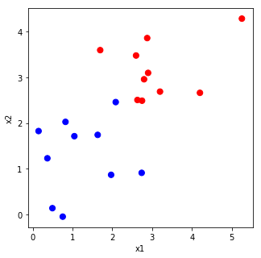

```
------------
Rodada #0

> x_i: [ 2.74523522  2.49114895  1.        ]
> w_i: [ 0.15937555 -0.46417832  1.        ]
> y_i: -1.0
> y_hat: 1.0
```

[figure not shown]

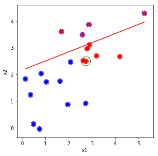

```
**********Atualizando pesos:
> w_i: [-0.11514797 -0.71329321  0.9       ]
```

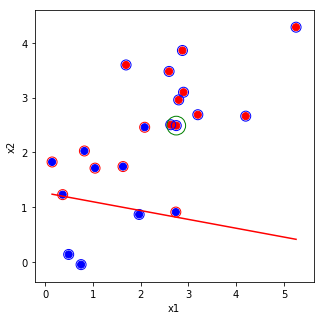

```
> x_i: [ 1.0455736   1.71416324  1.        ]
> w_i: [-0.11514797 -0.71329321  0.9       ]
> y_i: 1.0
> y_hat: -1.0
```

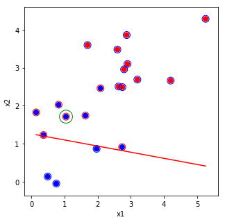

```
**********Atualizando pesos:
> w_i: [-0.01059061 -0.54187689  1.        ]
```

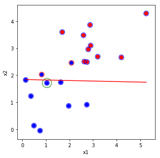

```
> x_i: [ 0.82308487  2.02768411  1.        ]
> w_i: [-0.01059061 -0.54187689  1.        ]
> y_i: 1.0
> y_hat: -1.0
```

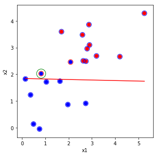

```
**********Atualizando pesos:
> w_i: [ 0.07171787 -0.33910848  1.1       ]
```

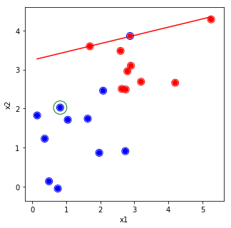

```
> x_i: [ 2.79615412  2.96074552  1.        ]
> w_i: [ 0.07171787 -0.33910848  1.1       ]
> y_i: -1.0
> y_hat: 1.0
```

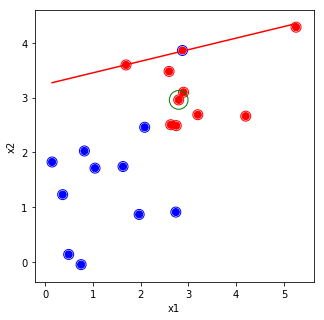

```
**********Atualizando pesos:
> w_i: [-0.20789754 -0.63518303  1.        ]
```

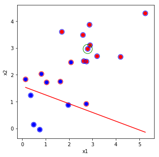

```
> x_i: [ 3.1964195   2.69015853  1.        ]
> w_i: [-0.20789754 -0.63518303  1.        ]
> y_i: -1.0
> y_hat: -1.0
```

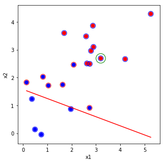

```
> x_i: [ 0.14701098  1.82653226  1.        ]
> w_i: [-0.20789754 -0.63518303  1.        ]
> y_i: 1.0
> y_hat: -1.0
```

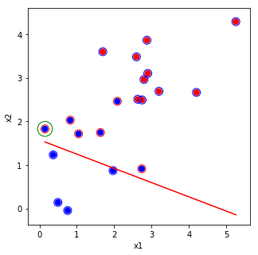

```
**********Atualizando pesos:
> w_i: [-0.19319644 -0.45252981  1.1       ]
```

[43 more figures not shown]

```
Vetor de pesos: [-0.0584491  -0.58419981  1.3       ]
```

|  | x1 | x2 | y | b | y_hat | right_answer |
| --- | --- | --- | --- | --- | --- | --- |
| 0 | 1.968472 | 0.867879 | 1.0 | 1 | 1.0 | 1.0 |
| 1 | 0.494191 | 0.137194 | 1.0 | 1 | 1.0 | 1.0 |
| 2 | 2.084225 | 2.460768 | 1.0 | 1 | -1.0 | -1.0 |
| 3 | 0.753627 | -0.048399 | 1.0 | 1 | 1.0 | 1.0 |
| 4 | 1.045574 | 1.714163 | 1.0 | 1 | 1.0 | 1.0 |
| 5 | 1.631302 | 1.742938 | 1.0 | 1 | 1.0 | 1.0 |
| 6 | 0.368196 | 1.230034 | 1.0 | 1 | 1.0 | 1.0 |
| 7 | 2.735856 | 0.911280 | 1.0 | 1 | 1.0 | 1.0 |
| 8 | 0.147011 | 1.826532 | 1.0 | 1 | 1.0 | 1.0 |
| 9 | 0.823085 | 2.027684 | 1.0 | 1 | 1.0 | 1.0 |
| 10 | 2.745235 | 2.491149 | -1.0 | 1 | -1.0 | 1.0 |
| 11 | 4.198725 | 2.663972 | -1.0 | 1 | -1.0 | 1.0 |
| 12 | 2.629070 | 2.507114 | -1.0 | 1 | -1.0 | 1.0 |
| 13 | 2.874378 | 3.863369 | -1.0 | 1 | -1.0 | 1.0 |
| 14 | 5.252017 | 4.289186 | -1.0 | 1 | -1.0 | 1.0 |
| 15 | 2.594821 | 3.481181 | -1.0 | 1 | -1.0 | 1.0 |
| 16 | 2.796154 | 2.960746 | -1.0 | 1 | -1.0 | 1.0 |
| 17 | 3.196420 | 2.690159 | -1.0 | 1 | -1.0 | 1.0 |
| 18 | 2.897434 | 3.100655 | -1.0 | 1 | -1.0 | 1.0 |
| 19 | 1.694513 | 3.599193 | -1.0 | 1 | -1.0 | 1.0 |

```python
for jj in range(1):
    ## Conjunto de treinamento

    train_case = 'w'
    n_samples  = 10

    if train_case == 'AND':
        # Conjunto para o caso AND
        df_train = pd.DataFrame({'x1': [1,1,0,0], 'x2': [1,0,1,0], 'y': [1,-1,-1,-1]})
        print 'Caso "AND"'
        display(df_train)

    elif train_case == 'XOR':
        # Conjunto para o caso AND
        df_train = pd.DataFrame({'x1': [1,1,0,0], 'x2': [1,0,1,0], 'y': [-1,1,1,-1]})
        print 'Caso "AND"'
        display(df_train)

    elif train_case == 'XOR':
        # Conjunto para o caso OR
        df_train = pd.DataFrame({'x1': [1,1,0,0], 'x2': [1,0,1,0], 'y': [1,1,1,-1]})
        print 'Caso "OR"'
        display(df_train)

    else:
        mu1 = 1
        mu2 = 1
        sigma1 = 1
        sigma2 = 1
        x1 = sigma1*np.random.randn(n_samples) + mu1
        x2 = sigma2*np.random.randn(n_samples) + mu2
        df_train = pd.DataFrame({'x1': x1, 'x2': x2})
        df_train['y'] = 1

        mu1 = 3
        mu2 = 3
        sigma1 = 1
        sigma2 = 1
        x1 = sigma1*np.random.randn(n_samples) + mu1
        x2 = sigma2*np.random.randn(n_samples) + mu2
        df_train = df_train.append(pd.DataFrame({'x1': x1, 'x2': x2}), ignore_index=True)
        df_train.ix[df_train.y.isnull(), 'y'] = -1


    # Funcao que treina o perceptron
    max_epoch = 2
    d = 2

    import pdb
    def evalPerceptron(df, w, b=None):
        #pdb.set_trace()
        """
        Funcao que avalia a resposta de um neuronio para varias entradas.
        """
        if (b is not None) and ('b' not in df.columns):
            df['b'] = 1
            w = np.append(w, b)
        y = np.sign(np.inner(df.drop('y', axis=1), w))
        df['y_hat'] = y
        df['right_answer'] = df.y_hat*df.y
        return df

    def trainPerceptron(df, max_epoch=1000, d='infer', learning_rate=0.2,
                        w_init=None, b_init=None, debug=False, writer=None, ax=None):
        """
        Funcao que treina um perceptron, realizando no maximo (max_epoch) ciclos.
        """
        if d == 'infer':
            d = df.shape[1] - 1
        if (w_init is None):
            w_init = np.zeros(d)
        if (b_init is None):
            b_init = np.array([1])

        w_i = np.append(w_init, b_init)
        d = d + 1
        df['b'] = 1

        for i_epoch in range(max_epoch):
            if debug: print '\n------------\nRodada #%s' % i_epoch
            for ni, x_i in df.sample(df.shape[0]).iterrows():
                y_i = x_i.pop('y')
                x_i = x_i.values
                y_hat = neuronEval(x_i, w_i)
                if debug:
                    print '\n> x_i:', x_i
                    print '> w_i:', w_i
                    print '> y_i:', y_i
                    print '> y_hat:', y_hat
                    df1 = evalPerceptron(df.copy(), w_i, b=None)
                    plotSepPlane(df1, w_i, x_i=x_i, ax=ax, writer=writer)
                if y_i*y_hat < 0:
                    w_i = w_i + learning_rate*y_i*x_i
                    if debug:
                        print '**********Atualizando pesos:\n> w_i:', w_i
                        df1 = evalPerceptron(df.copy(), w_i, b=None)
                        plotSepPlane(df1, w_i, x_i=x_i, ax=ax, writer=writer)

        print 'Vetor de pesos:', w_i
        return w_i

    display(df_train)
    plotSepPlane(df_train, None)

    import matplotlib
    matplotlib.use("Agg")
    import matplotlib.animation as manimation

    FFMpegWriter = manimation.writers['ffmpeg']
    metadata = dict(title='Movie Test', artist='Matplotlib',
                    comment='Movie support!')
    writer = FFMpegWriter(fps=5, metadata=metadata)


    fig, ax = plt.subplots(figsize=(10,10))
    ax.plot([], [], 'k-o')

    with writer.saving(fig, "%s_training_test.mp4" % jj, 100):
        w = trainPerceptron(df_train, max_epoch=2, w_init=(np.random.random(2) - 0.5),
                            learning_rate=0.1, d='infer', debug=True,
                            #writer=writer, ax=ax
                           )
        y = evalPerceptron(df_train, w)
        display(y)
```

## EX-3

### a)

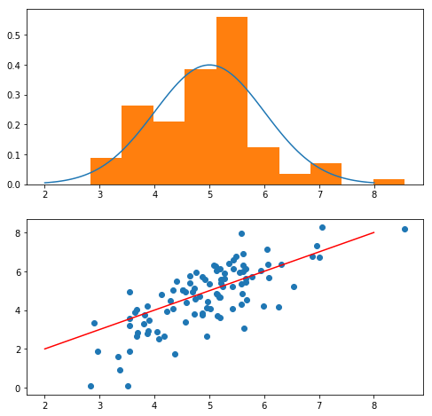

```python
import scipy.stats as stats

fig = plt.figure(figsize=(8, 8))
ax1 = fig.add_subplot(2, 1, 1)

# parâmetros da distribuição
mu = 5
sigma = 1
n_sample = 100

# distribuição normal com esses parâmetros
x_normal = np.linspace(mu-3*sigma, mu+3*sigma, 100)
normal_curve = stats.norm.pdf(x_normal, loc=mu, scale=sigma)
ax1.plot(x_normal, normal_curve, '-')

# distribuição da amostra
x = mu + sigma*np.random.randn(n_sample)
ax1.hist(x, normed=True)

ax2 = fig.add_subplot(2, 1, 2) #plt.show()

y = x + sigma*np.random.randn(n_sample)
ax2.scatter(x, y, marker='o')
ax2.plot(x_normal, x_normal, 'r-')
plt.show()
```

### b)

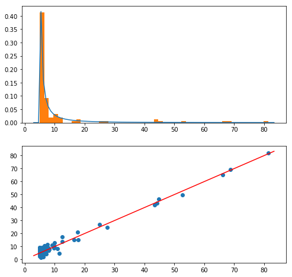

```python
import scipy.stats as stats

fig = plt.figure(figsize=(8, 8))
ax1 = fig.add_subplot(2, 1, 1)

# parâmetros da distribuição
mu = 5
sigma = 2
n_sample = 100

# distribuição da amostra
x = sigma*np.random.randn(n_sample)
x = mu + np.exp(x)
#x = np.random.lognormal(size=n_sample, mean=5, sigma=2)

# distribuição normal com esses parâmetros
x_normal = np.linspace(x.min() - sigma, x.max() + sigma, 100)
normal_curve = stats.lognorm.pdf(x_normal, sigma, loc=mu)

ax1.plot(x_normal, normal_curve, '-')
ax1.hist(x, normed=True, bins=(x.shape[0])/2)

ax2 = fig.add_subplot(2, 1, 2) #plt.show()

y = x + sigma*np.random.randn(n_sample)
ax2.scatter(x, y, marker='o')
ax2.plot(x_normal, x_normal, 'r-')
plt.show()
```

### c)

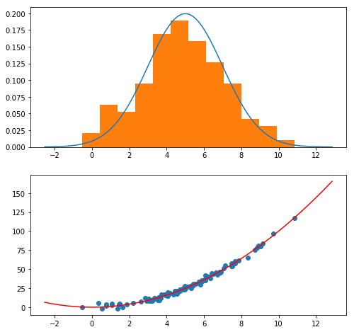

```python
import scipy.stats as stats

fig = plt.figure(figsize=(8, 8))
ax1 = fig.add_subplot(2, 1, 1)

# parâmetros da distribuição
mu = 5
sigma = 2
n_sample = 100

# distribuição da amostra
x = mu + sigma*np.random.randn(n_sample)

# distribuição normal com esses parâmetros
x_normal = np.linspace(x.min() - sigma, x.max() + sigma, 100)
normal_curve = stats.norm.pdf(x_normal, loc=mu, scale=sigma)

ax1.plot(x_normal, normal_curve, '-')
ax1.hist(x, normed=True, bins=(x.shape[0])/8)

ax2 = fig.add_subplot(2, 1, 2) #plt.show()

y = np.square(x) + sigma*np.random.randn(n_sample)
ax2.scatter(x, y, marker='o')
ax2.plot(x_normal, np.square(x_normal), 'r-')
plt.show()
```

### d)

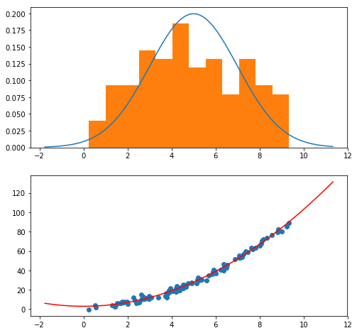

```python
import scipy.stats as stats

fig = plt.figure(figsize=(8, 8))
ax1 = fig.add_subplot(2, 1, 1)

# parâmetros da distribuição
mu = 5
sigma = 2
n_sample = 100

# distribuição da amostra
x = mu + sigma*np.random.randn(n_sample)

# distribuição normal com esses parâmetros
x_normal = np.linspace(x.min() - sigma, x.max() + sigma, 100)
normal_curve = stats.norm.pdf(x_normal, loc=mu, scale=sigma)

ax1.plot(x_normal, normal_curve, '-')
ax1.hist(x, normed=True, bins=(x.shape[0])/8)

ax2 = fig.add_subplot(2, 1, 2) #plt.show()

y = np.square(x) + 3 + sigma*np.random.randn(n_sample)
ax2.scatter(x, y, marker='o')
ax2.plot(x_normal, np.square(x_normal) + 3, 'r-')
plt.show()
```

### e)

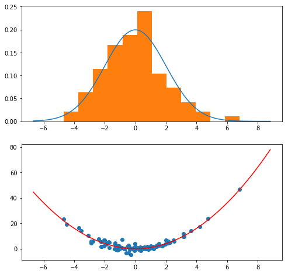

```python
import scipy.stats as stats

fig = plt.figure(figsize=(8, 8))
ax1 = fig.add_subplot(2, 1, 1)

# parâmetros da distribuição
mu = 0
sigma = 2
n_sample = 100

# distribuição da amostra
x = mu + sigma*np.random.randn(n_sample)

# distribuição normal com esses parâmetros
x_normal = np.linspace(x.min() - sigma, x.max() + sigma, 100)
normal_curve = stats.norm.pdf(x_normal, loc=mu, scale=sigma)

ax1.plot(x_normal, normal_curve, '-')
ax1.hist(x, normed=True, bins=(x.shape[0])/8)

ax2 = fig.add_subplot(2, 1, 2) #plt.show()

x = np.sort(x)
y = np.where(x > 0, np.square(x) + 1*np.random.randn(n_sample),
                    np.square(x) + 2*np.random.randn(n_sample))
ax2.scatter(x, y, marker='o')
ax2.plot(x_normal, np.square(x_normal), 'r-')
plt.show()
```

### f)

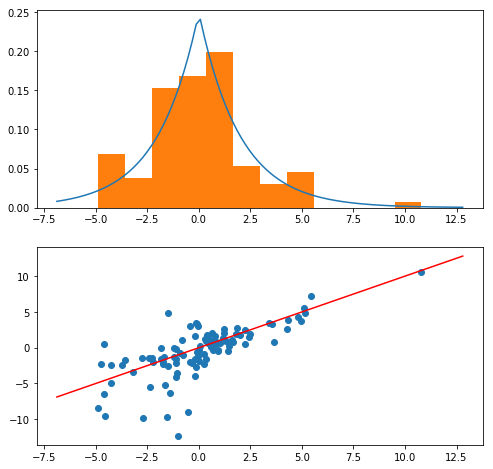

```python
import scipy.stats as stats

fig = plt.figure(figsize=(8, 8))
ax1 = fig.add_subplot(2, 1, 1)

# parâmetros da distribuição
mu = 0
sigma = 2
n_sample = 100

# distribuição da amostra
x = mu + sigma*np.random.randn(n_sample)
x = np.random.laplace(mu, sigma, n_sample)

# distribuição normal com esses parâmetros
x_normal = np.linspace(x.min() - sigma, x.max() + sigma, 100)
normal_curve = stats.norm.pdf(x_normal, loc=mu, scale=sigma)
normal_curve = stats.laplace.pdf(x_normal, loc=mu, scale=sigma)

ax1.plot(x_normal, normal_curve, '-')
ax1.hist(x, normed=True, bins=(x.shape[0])/8)

ax2 = fig.add_subplot(2, 1, 2) #plt.show()

x = np.sort(x)
y = np.where(x > 0, x + 1*np.random.randn(n_sample),
                    x + np.random.laplace(mu, 2, n_sample))
ax2.scatter(x, y, marker='o')
ax2.plot(x_normal, x_normal, 'r-')
plt.show()
```

## EX-4

Dado que:

$$ P(|R(f)-R_{emp}(f)| > \epsilon) < 2Kexp(-2\epsilon^2n) $$

Seja o intervalo de confiança definido como $1-\alpha$ e $\alpha$ definido como:

$$ \alpha = 2Kexp(-2\epsilon^2n) $$$$ ln(\alpha) = ln(2K) - 2\epsilon^2n $$$$ 2\epsilon^2n = ln(2K) - ln(\alpha) $$$$ \epsilon = \sqrt{\frac{ln(2K) - ln(\alpha)}{2n}} $$

E seja $\Omega(n, K)$:

$$ \Omega(n, K) = \sqrt{\frac{ln(2K) - ln(\alpha)}{2n}} $$

Tem se que:

$$ R_{emp}(f) - \Omega(n, K, \alpha) \leq R(f) \leq R_{emp}(f) + \Omega(n, K, \alpha) $$

## EX-5

Comentário do exercício resolvido no pdf:

```
"Also, any i > j, we will be adding an integral number of π/2 terms to a sine function, which causes no change in value".
```

Adicionar $\pi$ ao seno muda o sinal. Adicionar múltiplos de $2\pi$ que não mudaria.

Problema: Demonstrar de que o conjunto de funções $h(x)=sign(sin(ax+b))$ tem dimnesão VC infinita, a partir de um conjunto de pontos para o qual este conjunto de funções pode descrever qualquer estado possível:

Seja o conjunto de pontos $l$ pontos $X = \{x_1,...,x_l\}$, onde:

$$ x_i = 4^{-i} $$

Para qualquer conjunto $Y = \{y_1,...,y_l\}$ é possível definir

$$ a = \pi\left(\frac{1}{2} + \sum\limits_{i=1}^l \frac{(1-y_i)4^i}{2}\right) $$

e $b=0$ de tal maneira que qualquer que seja o conjunto Y ele seja "explicado" pela função $y_j = sign(sin(ax_j+b))$.

Prova:

Seja

$$ h(x_j) = sign\left(sin\left(4^{-j}*\pi\left(\frac{1}{2}+\sum\limits_{i=1}^l \frac{(1-y_i)4^i}{2}\right)\right)\right) $$$$ h(x_j) = sign\left(sin\left(\frac{4^{-j}\pi}{2} + \pi\left(\sum\limits_{i=1}^l \frac{(1-y_i)4^{i-j}}{2}\right)\right)\right) $$

Tirando o termo $i=j$ da somatória e dividindo em duas somatórias diferentes ( $i > j$ e $i < j$)

$$ h(x_j) = sign\left(sin\left(\frac{4^{-j}\pi}{2} + \frac{(1-y_j)\pi}{2} + \pi\left(\sum\limits_{i:i< j}^l \frac{(1-y_i)4^{i-j}}{2}\right) + \pi\left(\sum\limits_{i:i>j}^l \frac{(1-y_i)4^{i-j}}{2}\right)\right)\right) $$

e só considerando $y_j=-1$ nas somatórias (dado que para $y_j=1$ o termo vale zero

$$ h(x_j) = sign\left(sin\left(\frac{4^{-j}\pi}{2} + \frac{(1-y_j)\pi}{2} + \pi\left(\sum\limits_{i:i< j,y_j=-1}^l \frac{(2)4^{i-j}}{2}\right) + \pi\left(\sum\limits_{i:i>j,y_j=-1}^l \frac{(2)4^{i-j}}{2}\right)\right)\right) $$$$ h(x_j) = sign\left(sin\left(\frac{4^{-j}\pi}{2} + \frac{(1-y_j)\pi}{2} + \pi\left(\sum\limits_{i:i< j,y_j=-1}^l 4^{i-j}\right) + \pi\left(\sum\limits_{i:i>j,y_j=-1}^l 4^{i-j}\right)\right)\right) $$

e

$$ \pi\left(\sum\limits_{i:i< j,y_j=-1}^l 4^{i-j}\right) \leq \frac{\pi}{2} $$

## EX-6

##### Questão:

Supondo que você está trabalhando com classificação de textos, onde o número de exemplos de treinamento costuma ser bem menor que o número de dimensões, por que o Lasso seria preferível ao OLS?

##### Resposta:

Quando o número de exemplos de treinamento é menor que o número de dimensões da função de regressão, existe o problema de a função estimada "overfitar" os dados. Isso acontece porque sua capacidade é grande demais para o número de exemplos disponíveis. Logo, o Lasso, por conseguir escolher menos parâmetros do que a dimensão máxima $d$ pode resultar em modelos bons, enquanto o OLS, ao usar todos os $d$ parâmetros, iria provavelmente causar "overfitting" dos dados.

## EX-7

##### Questão:

Pense e descreva um esquema para implementar controle de capacidade no algoritmo naive Bayes (qualquer que seja o tipo).

##### Resposta:

Pensando em um Naïve Bayes multinomial para classificação de texto (o clássico exemplo do spam/não spam), onde se usa a frequência com que as palavras aparecem nos documentos para classificá-lo como pertencente a alguma das classes, pode se controlar a capacidade do algoritmo controlando o número de palavras utilizadas para classificar os documentos. Em vez de utilizar todas as palavras do documento que aparecem no conjunto de treinamento, utilizar somente as $d$ palavras que mais diferenciam entre as classes. Ou seja, as $d$ palavras para as quais existe a maior diferença entre as probabilidades:

$$ P(C_1|x=x_i) - P(C_2|x=x_i) $$